# STAT 689 Homework 9

## Rohan Tiwari

This is an open-ended question but based on the ragweed data, Exercise 11 in Chapter 3. You may have to consult the book carefully to do the exercise. The response is the pollen count. The idea of the square root transformation of the pollen count is based on the well-known result that if the Poisson counts are pretty common, their square root is approximately normally distributed and with approximately constant variance. This arises from a delta-method calculation. The place of this study is Kalamazoo, MI. It used to be a nice town but appears to have fallen on hard times. Western Michigan University is based there.

### 1. Work Exercise 3.11.a.

```r
library(HRW)
data(ragweed)
help(ragweed)
```

```
## starting httpd help server ... done
```

### 2. Use the model in Exercise 3.11.b, but fit a quasiPoisson model with scale = -1, family=quasipoisson. Based on the estimated scale (= c^2 of the lectures), might there be concern about overdisperson? Why or why not? The base model is

fit1 <- gam(pollenCount ~ factor(year) + s(dayInSeason,k = 27,by = factor(year)) + temperatureResidual + rain + s(windSpeed,k = 27), data = ragweed,family = quasipoisson,scale=-1)

```r
fit1 <- mgcv::gam(pollenCount ~ factor(year)
+ s(dayInSeason,k = 27,by = factor(year))
+ temperatureResidual + rain + s(windSpeed,k = 27),
data = ragweed,family = quasipoisson,scale=-1)
summary(fit1)
```

```
##
## Family: quasipoisson
## Link function: log
##
## Formula:
## pollenCount ~ factor(year) + s(dayInSeason, k = 27, by = factor(year)) +
##     temperatureResidual + rain + s(windSpeed, k = 27)
##
## Parametric coefficients:
##                      Estimate Std. Error t value Pr(>|t|)
## (Intercept)          2.008789   0.184479  10.889  < 2e-16 ***
## factor(year)1992    -0.483085   0.389142  -1.241   0.2155
## factor(year)1993    -0.556736   0.229638  -2.424   0.0160 *
## factor(year)1994    -1.129297   0.449265  -2.514   0.0125 *
## temperatureResidual  0.047169   0.006997   6.741 8.94e-11 ***
## rain                 0.853755   0.161041   5.301 2.33e-07 ***
## ---
## Signif. codes:  0 '***' 0.001 '**' 0.01 '*' 0.05 '.' 0.1 ' ' 1
##
## Approximate significance of smooth terms:
##                                    edf Ref.df      F p-value
## s(dayInSeason):factor(year)1991  7.905  9.782 47.793  <2e-16 ***
## s(dayInSeason):factor(year)1992 11.733 14.158 24.058  <2e-16 ***
## s(dayInSeason):factor(year)1993  7.667  9.517 32.056  <2e-16 ***
## s(dayInSeason):factor(year)1994  5.875  7.336 21.071  <2e-16 ***
## s(windSpeed)                    14.654 17.530  5.367  <2e-16 ***
## ---
## Signif. codes:  0 '***' 0.001 '**' 0.01 '*' 0.05 '.' 0.1 ' ' 1
##
## R-sq.(adj) =  0.879   Deviance explained = 92.3%
## GCV = 9.5977  Scale est. = 8.5443    n = 334
```

The scale estimate is 8.5443 which is greater than 1 or it is not close to 1. Therefore, as per lecture slides, we have over dispersion.

### 3. Now take the square root transformation of the response, and pretending that the well-known theory is correct, check to see whether the idea of constant variance after the square root transformation is reasonable in this example

### 3a. This means first to fit the model above, with the response being the square root of the pollen counts, but with no scale and family=gaussian

```r
fit2 <- mgcv::gam(sqrt(pollenCount) ~ factor(year)
+ s(dayInSeason,k = 27,by = factor(year))
+ temperatureResidual + rain + s(windSpeed,k = 27),
data = ragweed,family = gaussian)
summary(fit2)
```

```
##
## Family: gaussian
## Link function: identity
##
## Formula:
## sqrt(pollenCount) ~ factor(year) + s(dayInSeason, k = 27, by = factor(year)) +
##     temperatureResidual + rain + s(windSpeed, k = 27)
##
## Parametric coefficients:
##                     Estimate Std. Error t value Pr(>|t|)
## (Intercept)          3.60601    0.35948  10.031  < 2e-16 ***
## factor(year)1992     0.09090    0.29382   0.309 0.757277
## factor(year)1993    -0.20278    0.26391  -0.768 0.442920
## factor(year)1994    -1.13137    0.31720  -3.567 0.000425 ***
## temperatureResidual  0.10174    0.01902   5.348 1.85e-07 ***
## rain                 1.53507    0.34149   4.495 1.02e-05 ***
## ---
## Signif. codes:  0 '***' 0.001 '**' 0.01 '*' 0.05 '.' 0.1 ' ' 1
##
## Approximate significance of smooth terms:
##                                    edf Ref.df      F p-value
## s(dayInSeason):factor(year)1991 15.226 18.434 29.971  <2e-16 ***
## s(dayInSeason):factor(year)1992  9.305 11.504 44.530  <2e-16 ***
## s(dayInSeason):factor(year)1993 10.170 12.578 48.865  <2e-16 ***
## s(dayInSeason):factor(year)1994  5.689  7.078 47.483  <2e-16 ***
## s(windSpeed)                     7.798  9.655  6.015  <2e-16 ***
## ---
## Signif. codes:  0 '***' 0.001 '**' 0.01 '*' 0.05 '.' 0.1 ' ' 1
##
## R-sq.(adj) =  0.867   Deviance explained = 88.8%
## GCV = 3.5274  Scale est. = 2.9551    n = 334
```

### 3b. Create the residuals from your fit. Call them R.

```r
r = residuals(fit2)
```

### 3c. Create the absolute values of the residuals from your fit, i.e., abs(R). Called them A.

```r
a = abs(r)
```

### 3d. Regress A on the same model as in question 3.a. Get the fitted values and call them F.

```r
fit3 = mgcv::gam(a ~ factor(year)
+ s(dayInSeason,k = 27,by = factor(year))
+ temperatureResidual + rain + s(windSpeed,k = 27),
data = ragweed,family = gaussian)

f = fitted(fit3)
```

### 3e. Regress the absolute residuals A on F as in a simple linear regression. Plot the fitted model

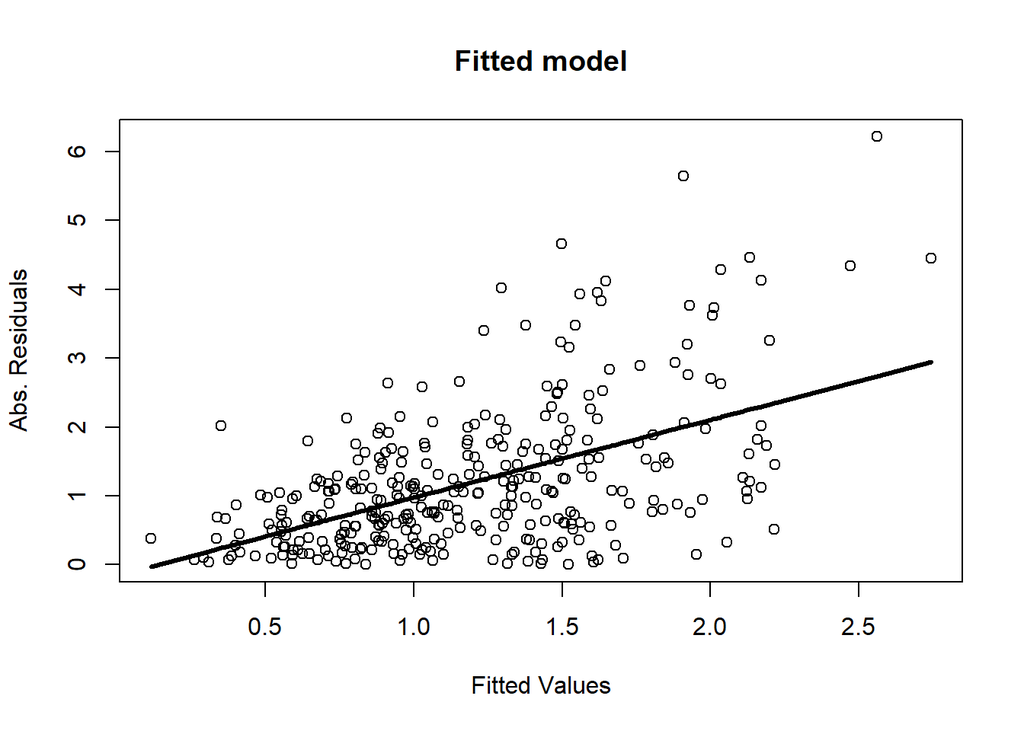

```r
fit4 = lm(a ~ f)
ord <- order(f)
plot(f[ord], a[ord]
     , main="Fitted model"
     , xlab="Fitted Values"
     , ylab="Abs. Residuals"
     )
# plot the model
lines(f[ord], fitted(fit4)[ord], lwd=3)
```

### 3f. Do you see evidence of severe heteroscedasticity in that plot?

Variance of abs. residuals greatly increases as we move towards the right; their variance is not constant so we have severe heterscedasticity.

### 4. Using the square root transformation of pollen counts as the response as in question 3, replace the statement s(dayInSeason,k = 27,by = factor(year)) by s(dayInSeason,k = 27), i.e., remove the interaction from the model with the square root transformation. Do a stepwise regression using gam in the gam package, i.e., gam::step.Gam. Make sure that that you have detached the mgcv package first. What model is selected?

```r
#It appears that if you have been playing around with code, that has called mgcv, you have to detach the package, or use gam::gam
if("package:mgcv" %in% search()) detach("package:mgcv", unload=TRUE)
library(gam)
fit5 <- gam::gam(sqrt(pollenCount) ~ factor(year)
+ dayInSeason + temperatureResidual + rain + windSpeed,
data = ragweed,family = gaussian)
summary(fit5)
```

```
##
## Call: gam::gam(formula = sqrt(pollenCount) ~ factor(year) + dayInSeason +
##     temperatureResidual + rain + windSpeed, family = gaussian,
##     data = ragweed)
## Deviance Residuals:
##      Min       1Q   Median       3Q      Max
## -10.3928  -1.8765  -0.4902   1.6597  12.5348
##
## (Dispersion Parameter for gaussian family taken to be 13.999)
##
##     Null Deviance: 7380.908 on 333 degrees of freedom
## Residual Deviance: 4563.663 on 326 degrees of freedom
## AIC: 1839.174
##
## Number of Local Scoring Iterations: 2
##
## Anova for Parametric Effects
##                      Df Sum Sq Mean Sq  F value    Pr(>F)
## factor(year)          3   84.0   28.01   2.0009  0.113714
## dayInSeason           1 2299.1 2299.12 164.2353 < 2.2e-16 ***
## temperatureResidual   1  270.4  270.39  19.3153 1.501e-05 ***
## rain                  1  119.7  119.68   8.5489  0.003699 **
## windSpeed             1   44.0   44.02   3.1445  0.077117 .
## Residuals           326 4563.7   14.00
## ---
## Signif. codes:  0 '***' 0.001 '**' 0.01 '*' 0.05 '.' 0.1 ' ' 1
```

```r
fit5stepwise = gam::step.Gam(fit5, scope =
                               list("year" = ~1 + factor(year)
                                    ,"dayInSeason" = ~1 +  dayInSeason + s(dayInSeason, 4)
                                    , "temperatureResidual" = ~1 + temperatureResidual  + s(temperatureResidual, 4)
                                    , "rain" = ~1 + rain
                                    , "windSpeed" = ~1 + windSpeed + s(windSpeed, 4))
                             , data = ragweed,family = gaussian)
```

```
## Start:  sqrt(pollenCount) ~ factor(year) + dayInSeason + temperatureResidual +      rain + windSpeed; AIC= 1839.174
## Step:1 sqrt(pollenCount) ~ factor(year) + s(dayInSeason, 4) + temperatureResidual +      rain + windSpeed ; AIC= 1513.114
```

```r
#print final model
print(names(fit5stepwise$"model")[-1])
```

```
## [1] "factor(year)"        "s(dayInSeason, 4)"   "temperatureResidual"
## [4] "rain"                "windSpeed"
```

Model selected is [1] “factor(year)” “s(dayInSeason, 4)” “temperatureResidual” “rain”  
[5] “windSpeed”